# Bioinformatics Assignment 2

```r
# Define file paths
data_dir <- file.path("../../data", "SRP164913")
data_file <- file.path(data_dir, "SRP164913_HUGO.tsv")
metadata_file <- file.path(data_dir, "metadata_SRP164913.tsv")
results_dir <- file.path("../../results")
plots_dir <- file.path("plots")

# Libraries
library(DESeq2)
library(ggplot2)
library(magrittr)
library(M3C)
library("umap")
# Set seed for reproducible results
set.seed(12345)
```

**Group:** 5, **Date:** 09/25/2024 Order to run R scripts:  
(task 1) preprocessing.R  
(task 2) PCA_Plot.R  
(task 3) DifferentialAnalysis.R  
(task 4) heatmap.R  
(task 5-Hannah) gprofiler2.R

## Task 1 - Data analysis

### Sample Size

```r
data_analysis_df <- read.delim("../../data/SRP164913/SRP164913_HUGO.tsv",header = TRUE, row.names = 1, stringsAsFactors = FALSE)
cat("Number of Genes in the expression matrix: ", dim(data_analysis_df)[1], "\n")
```

```
## Number of Genes in the expression matrix:  29589
```

```r
cat("Number of Samples in the expression matrix: ", dim(data_analysis_df)[2], "\n")
```

```
## Number of Samples in the expression matrix:  88
```

There are 88 samples, however, there are three disease groups: healthy controls, MS subjects, and ham/tsp subjects. To make this a binary problem, from Task 2 onward, we removed the ham/tsp subjects to compare only MS vs healthy controls (hc). This reduces the number of samples to 62.

### Density Plot of Gene Expressions

```r
# Get the median of expressions by gene
gene_median <- apply(data_analysis_df, 1, median)
head(gene_median)
```

```
##     A1BG A1BG-AS1     A1CF      A2M  A2M-AS1    A2ML1
##        0        0        0        0        0        0
```

```r
gene_median = log2(gene_median +1)
cat("Variance between gene expression medians:", var(gene_median, na.rm = TRUE))
```

```
## Variance between gene expression medians: 0.1234497
```

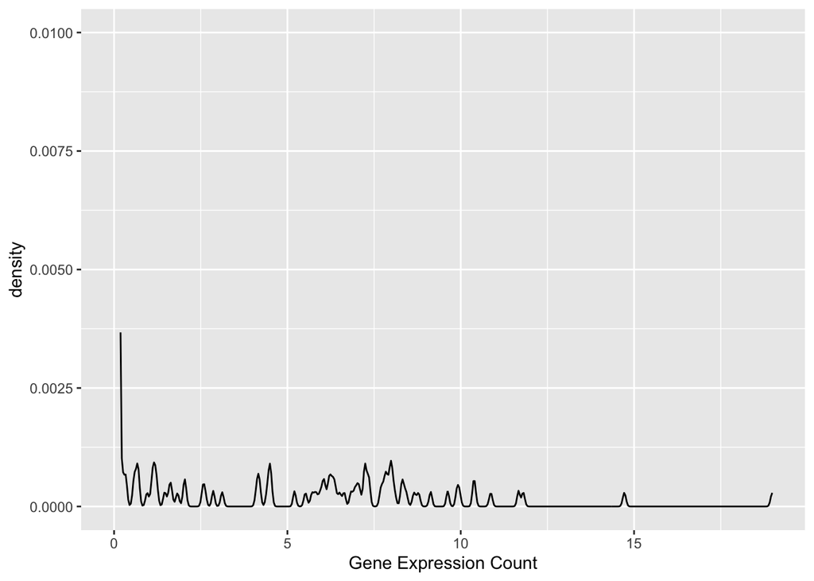

```r
# Create a Data frame from the numerical array
gene_median_df <- data.frame(Median = gene_median)
# Plot the values
ggplot(gene_median_df, aes(x = Median)) + geom_density() + xlab("Gene Expression Count") + ylim(0,1e-2)
```

## Task 2 - Principal Component Analysis

We were able to get a PCA, tsne, and umap plot following the tutorials. All three show a clear difference between the healthy control (hs) and MS (ms) groups, with a few samples in the midst of the other cluster. The number of crossovers is different.

### PCA Plot

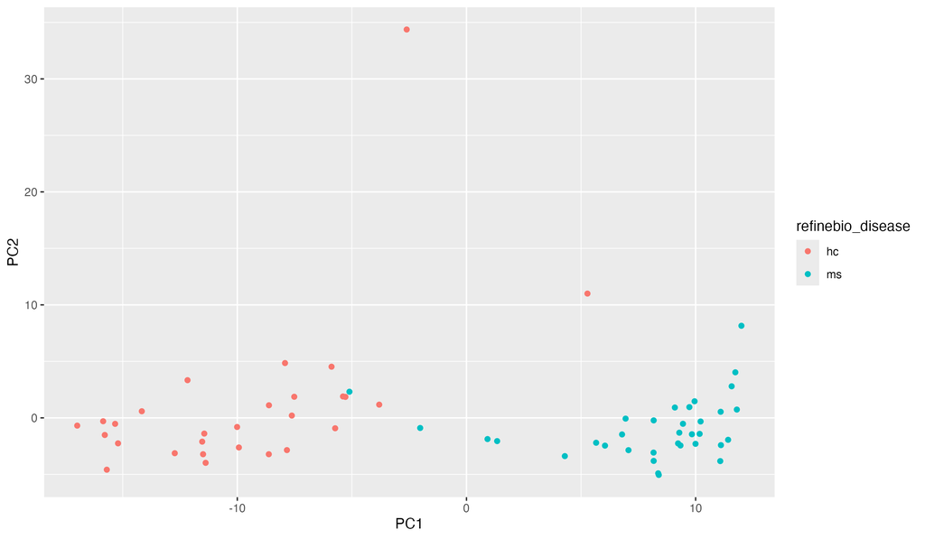

PCA Plot

### TSNE Plot

The TSNE (t-distributed stochastic neighbor embedding) plot visualizes n-dimensional data in two dimensions. Using this method, our data is nicely split in two clusters, with a few outliers in the wrong cluster. This gives a frist hint, that there are some differentially expressed genes among the two groups, Multiple Sclerosis and Human Control.

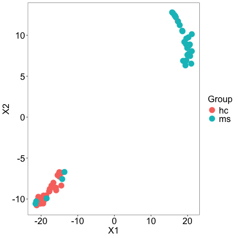

### UMAP Plot

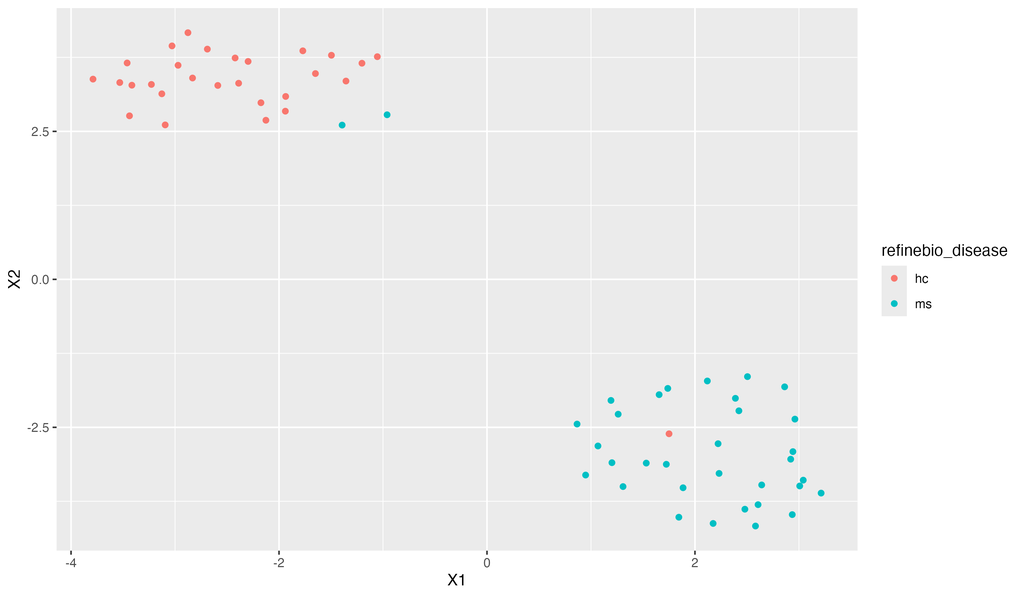

umap Plot

## Task 3 - Differential Analysis

When we did our differential analysis, because the data was so small and normalized, we had to adjust the filter value to 0.01 or else only ~1000 rows were making it to the DESeqDataSetFromMatrix() step. This was causing our volcano plot to look very sparse. We were able to get a list of the top 50 differentially expressed genes. The results, both the entire table and only the top 50, are stored in the results folder.

```r
top_50_file <- file.path(results_dir, "SRP164913_diff_expr_top_50_results.tsv")
top_50 <- readr::read_tsv(top_50_file)
head(top_50)
```

| Gene | baseMean | log2FoldChange | lfcSE | pvalue | padj | threshold |
| --- | --- | --- | --- | --- | --- | --- |
| TRBV23-1 | 9.452899 | 2.3391353 | 0.6143507 | 1.679175e-04 | 6.519149e-03 | TRUE |
| TRBV16 | 18.908626 | 1.6278672 | 0.4236125 | 6.333398e-02 | 6.634988e-02 | FALSE |
| TRBV7-7 | 557.184735 | 1.3903257 | 0.2687308 | 1.374014e-08 | 1.578574e-06 | TRUE |
| TRBV7-4 | 31.721892 | 1.1464073 | 0.3620274 | 1.076503e-04 | 4.349949e-03 | TRUE |
| TRBV12-4 | 388.803712 | 1.0244375 | 0.5086922 | 8.367126e-04 | 2.342925e-02 | TRUE |
| TRBV15 | 728.841711 | 0.9355824 | 0.1716974 | 2.468363e-09 | 3.258240e-07 | TRUE |

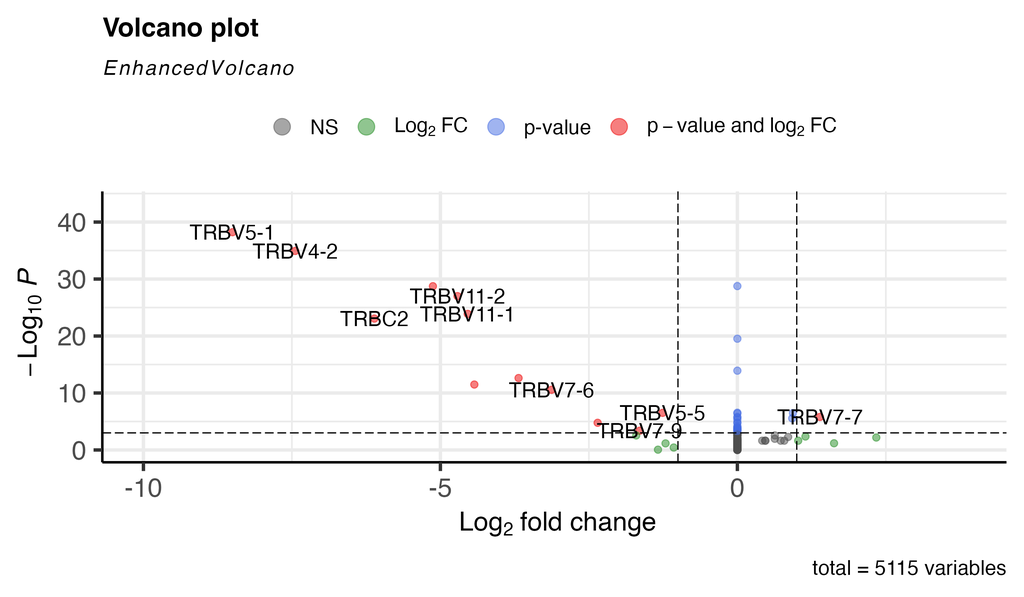

The volcano plot, while still somewhat sparse, is far more populated than it was with the highly filtered data. Most significant results have a negative log fold change.

## Task 4 - Heatmap

A heatmap was generated for the top 50 differentially expressed genes. The counts for each gene in the top 50 were extracted and put into the heatmap plot. It was annotated with the two disease groups: ms subjects and healthy control subjects. Since many of our counts are 0 and therefore are not expressed differently, the map is largely blue.

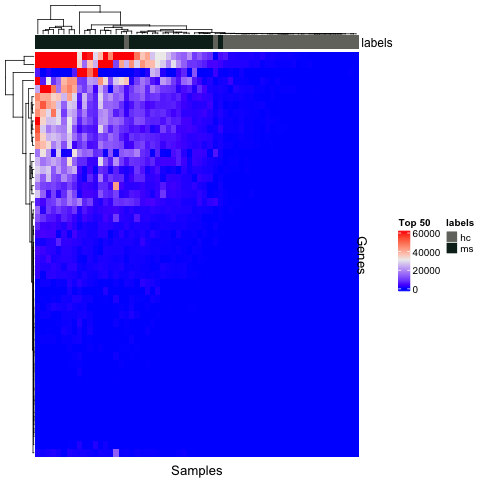

Heatmap

## Task 5 - Enrichment Analysis

### Hannah- gprofiler2

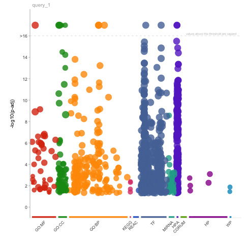

```r
results_dir <- file.path("../../results")
diff_expr_file <- file.path(results_dir, "SRP164913_diff_expr_results.tsv")
library(gprofiler2)
diff_expr_df <- readr::read_tsv(diff_expr_file)
gost_res3 <- gost(
  query = unlist(diff_expr_df[diff_expr_df$padj<0.05, 'Gene']),
  significant=TRUE,
  organism = "hsapiens"
  )
head(gost_res3$results)
```

When I had initially tried to run gost with every gene name, no p-value factor, it would produce a result that could be printed, but that is not as relevant to our dataset. This does prove that something is off with specifically the differential data, and the function does work.

Unfortunatly, due to the circumstances described above, no table was generated using the gprofiler2 method.

### Luca - topGO

Given a set of genes and a gene differential expression analysis, topGo enriches the most relevant Genes with Gene Ontology (GO) terms. This helps to find out what function the differential expressed genes perform in the Human Body.

#### Methodology

The Mothodology described is analogous to the Quick Start Guide found here “https://bioconductor.org/packages/release/bioc/vignettes/topGO/inst/doc/topGO.pdf”. The Output of Task 1-4 was a list of differential expressed genes, with their probability, only trivial transformations were required to input the data into the topGO function which returns an object containing all gene identifiers and their scores, GO annotations and further information. The cutoff for expressed gene selection has been set to the default of p<0.05.

Using the Fisher exact test a enrichment analysis is performed, testing for the over-representation of GO terms within the differentially expressed genes. Due to time constraints only the classic method, testing each GO category independently was used.

#### Results:

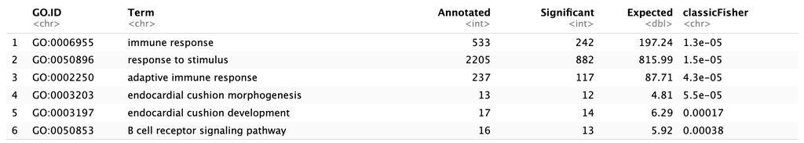

The Table above, shows the first few rows of the enrichment analysis. Although the issues with the pre-normalized data mentioned in the introduction, parts of the result seem plausible to the untrained eye in regard to the disease Multiple Sclerosis (This is the first time I actually experienced joy during this assignment). In multiple sclerosis MS, the immune system attacks the protective cover on nerve, causing communication problems between the brain and the rest of the body. Due to this pathology it is coherent, that the top differential expressed genes found during the enrichment analysis, are genes and receptors linked to the immune system. Below the most significant 5 nodes are represented as a tree.

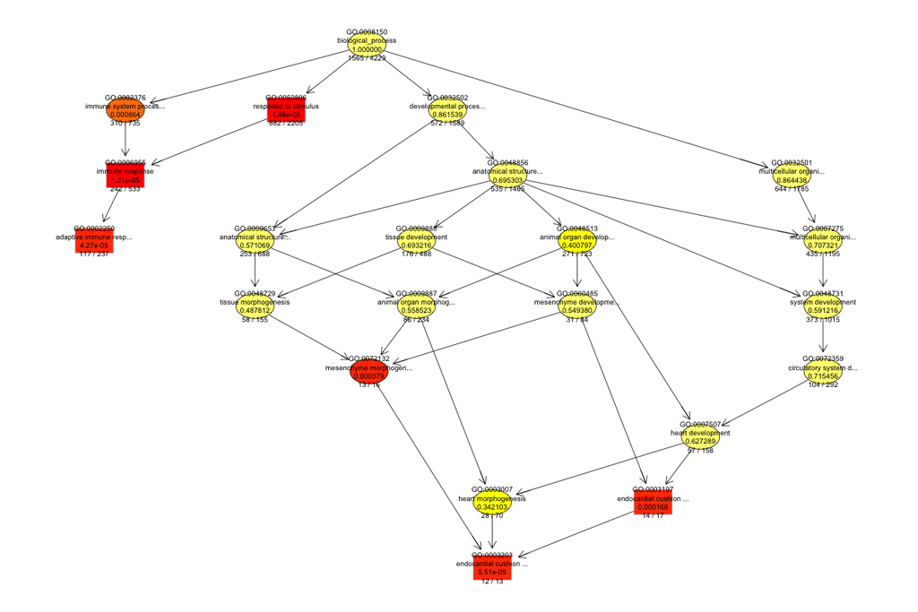

#### Fisher vs Elim

Due to time constraint, only Fisher’s exact test was used to generate the above results. To visualize the potential differences the following plot, shows that the Elim test would yield higher p-values for multiple genes, while some are identical for both methods.

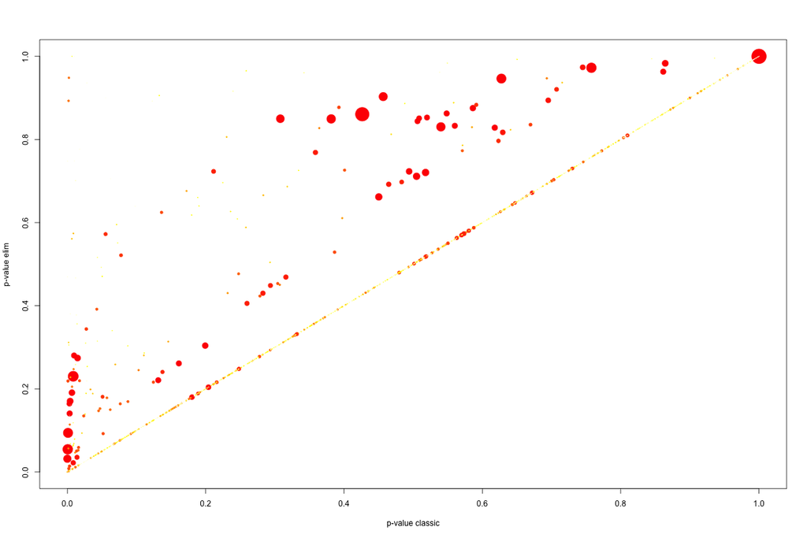

## Task 6/7 - Joint Enrichment Analysis